# Multivariate Feature Optimization

[Ryan Tillis](http://www.ryantillis.com)

August 15, 2016

## Synopsis

In this project we explore the relationship between miles per gallon (MPG) and a set of variables from the Motor Trends car dataset. We are particularly interested in the following two questions:

- Is an automatic or manual transmission better for MPG?
- How can we quantify the difference in MPG between manual and automatic transmissions?

A variety of models are possible, it is quickly apparent that manual is significantly better for gas mileage than automatic. The initial t.test shows this. Specifically quantifying the amount requires accounting for all other regressor while maintaining low variance and high accuracy.

Adjusted R^2 is a good way to adjust for the change in variance when adding reggressors. By optimizing our model for adjusted R^2 we arrive at a model with a high multiple R^2 value and low standard error which achieves a significant P-value.

### Hypothesis Test

First is a t.test for whether manual transmission has a significantly higher mean than automatic (in Mmpg). The data-splitting is included in the appendix

```r
t.test(manual$mpg,auto$mpg,alternative = "less")$p.value
```

```
## [1] 0.0006868192
```

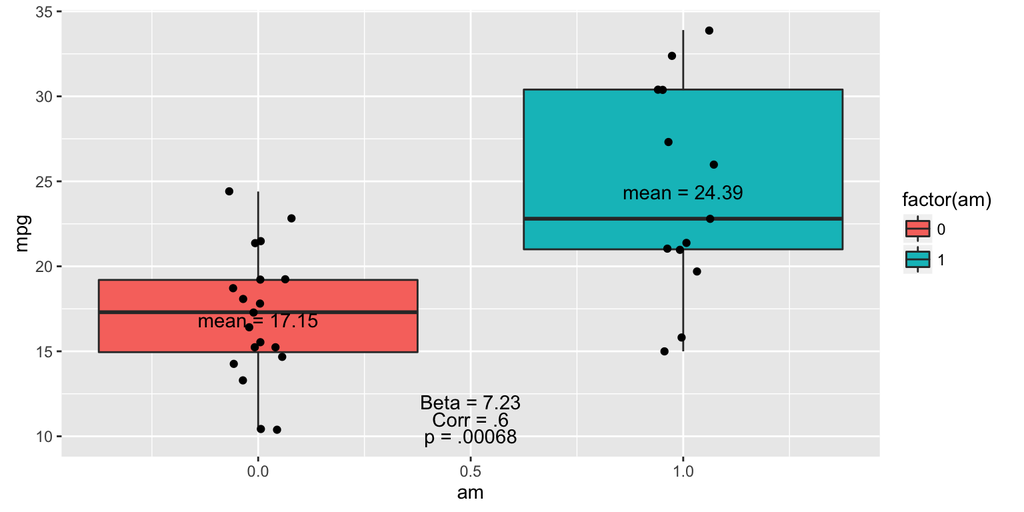

## Model/feature Selection

Fitall uses all variables as regressors, this has a maximus R^2 but high variance

```r
sumopt #mpg ~ am + disp + hp + wt + qsec
```

[output not shown]

```r
sumall# mpg ~ am + cyl + disp + hp + drat + wt + qsec + vs + gear + carb
```

[output not shown]

```r
sum1 # mpg ~ am
```

[output not shown]

## Appendix

```r
require(datasets); require(plyr); require(ggplot2);
require(GGally);require(car);data(mtcars);attach(mtcars)
```

```r
auto <- mtcars[which(am==1),]
manual <- mtcars[which(am==0),]
```

```r
fitmem = {0}
memdex = {0}
       #Removing mpg and am from regressor list since they are necessary for our purposes
       regressors <- names(mtcars)[c(2:8,10:11)]

       #Generating a binary matrix for using each regressor or not in a grid matrix
       usematrix <- expand.grid(c(TRUE,FALSE), c(TRUE,FALSE),
                             c(TRUE,FALSE), c(TRUE,FALSE),c(TRUE,FALSE), c(TRUE,FALSE),
                             c(TRUE,FALSE), c(TRUE,FALSE))

       #Creates a list of all possible regressor cominations, there are 256
       Models <- apply(usematrix, 1, function(x) as.formula(paste(c("mpg ~ am", regressors[x]), collapse=" + ")))
       #Applies linear models to all of the possible functions and stores in list
       df <- lapply(Models,lm,data =mtcars)

       #Loops over the list storing the max value for adjusted R^2 and the corresponding index
       for (i in 1:256){
              if (summary(df[[i]])$adj.r.squared > fitmem) {
                     fitmem <- summary(df[[i]])$adj.r.squared
                     memdex <- i
              }
              fitmem
              memdex
       }
```

```r
append(summary(df[[memdex]])$coef[2,],summary(df[[memdex]])$adj.r.squared)
sumopt <- append(summary(df[[memdex]])$coef[2,],summary(df[[memdex]])$adj.r.squared)
names(sumopt)[5] <- "Adj R^2"

append(summary(fitall)$coef[2,],summary(fitall)$adj.r.squared)
sumall <- append(summary(fitall)$coef[2,],summary(fitall)$adj.r.squared)
names(sumall)[5] <- "Adj R^2"

append(summary(fit1)$coef[2,],summary(fit1)$adj.r.squared)
sum1 <- append(summary(fit1)$coef[2,],summary(fit1)$adj.r.squared)
names(sum1)[5] <- "Adj R^2"
```